# Accelerometers

Giuseppa Cefalu

2024-05-20

INTRODUCTION

In order to build a model for the data, I tested several models: “knn”, “tree”, “random forest”, “lda”, linear svm, radial svm, and “lda2”. Linear svm confusion excluded from consideration due to the large ammount of time taken by the algorithm to complete. The rest of the models were tested using a validation set and a test set, and the choice of model was based on accuracy, kappa, confusion matrix, statistics by class, and the ROC curve. Additionally, I ploted the distributions predicted by the models for the validation and test sets. I could observe that most of the models predicted a very similar distribution for the training set and for the validation set, but they predicted a very diffferent one for the testing set. That indicates, in the case of the best models, that the models are fitted to the data. Also, I checked the performance of the algorithms by using the resample package. This resulted in model “knn” being the best which coincides with my observations?

DATA PREPROCESSING

Before the models were built, a correlation calculation of the data sets was performed to look for collinearities. A few variables were eliminated from the data sets due to high correlation (“> 8.0”).

ZERO AND NEAR ZERO VARIABLES

The data sets were tested for zero or near zero variability variables and the identified variables were removed from the data sets. Without removing the zero or near zero variability variables, the “tree” algorithm brakes.

SAMPLE SIZE

Not only the distribution of the test set was very different, but also the sample size, - the sample size of the test set was much smaller than the sample size of the training and validation sets. This led me to conclude that the model predictions are affect by the size of the data sets, since being the testing set such a small set, its distribution cannot include all the population frequencies variability and therefore, does not represent the population. A larger data set is need to build the models so that they can generalize better to the population.

DATA DISTRIBUTIONS

To get an idea of the data distribution of the different sets “training”, “validation”, and “testing” I performed a summary statistics of the 3 data sets. The data distributions of the training and validation set were very similar, while the diatrbution of the testing set was very different from the data distribution of the other 2 sets. Due to space constrains, only the plots are shown here. I could not plot the testing set data distribution because the classification variable is missing from That file.

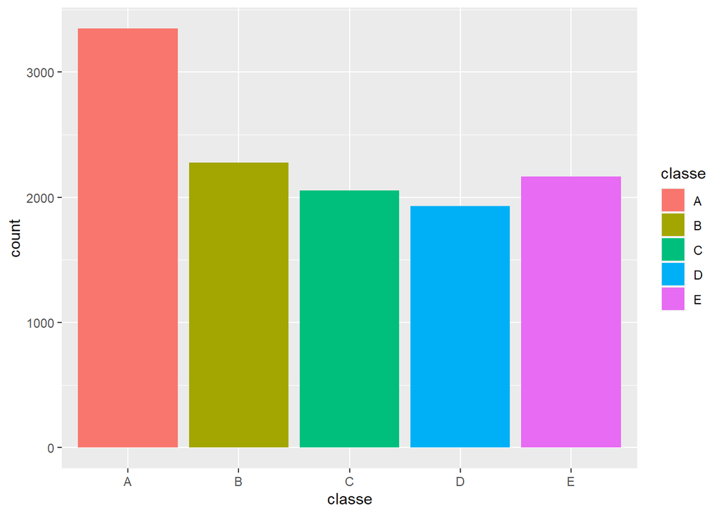

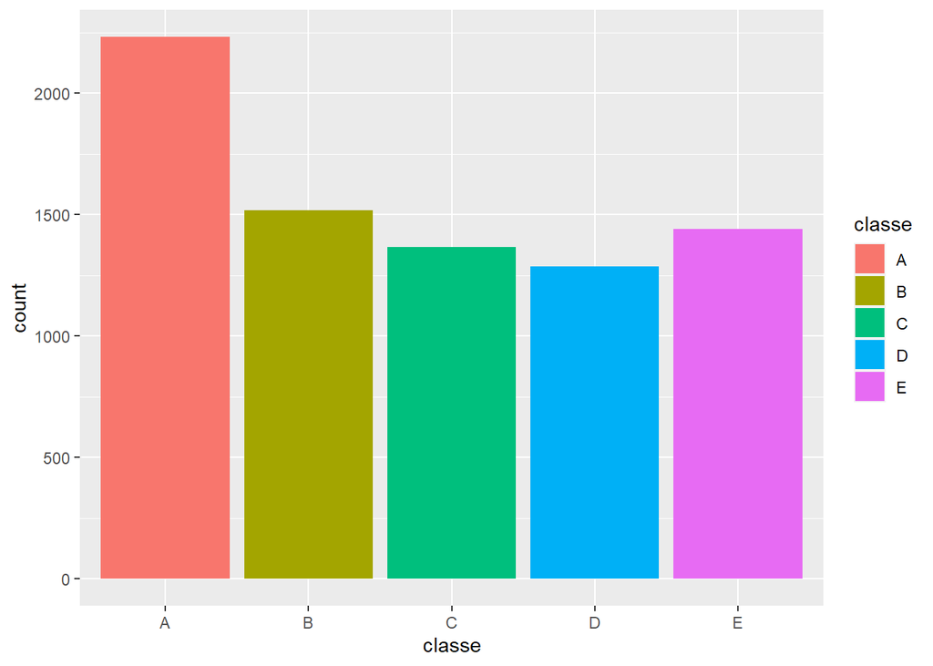

KNN MODEL

For this model, 2 values are passed in our “preProcess” parameter “center” & “scale”. These two help for centering and scaling the data. After preProcessing these convert our training data with mean value as approximately “0” and standard deviation as “1”. distance based algorithms are affected by the scale of the variables. Number is the number of folds. repeats = For repeated k-fold cross-validation only: the number of complete sets of folds to compute. Three separate 10 cross validaton are done here.

TUNING PARAMETERS

The “tuneLength” parameter holds an integer value. This is for tuning our algorithm. TuneLength is equivalent to tuneGrid. It indicates the number of values to use for each validation and is setup automatically.One method of searching for the ‘optimal’ model parameters is using random selection. In this case the tuneLength argument is used to control the number of combinations generated by this random tuning parameter search.

[output not shown]

However, sometimes the defaults are not the most sensible given the nature of the data. The tuneGrid argument allows the user to specify a custom grid of tuning parameters as opposed to simply using what exists implicitly. In the grid, each algorithm parameter can be specified as a vector of possible values.

The choice of parameters was made by the model based on measures of “accuracy” and “Kappa”. Below is a list of the parameters tested by the model and the corresponding measures of accurcy based on which K was selected. The k value in the k-NN algorithm defines how many neighbors will be checked to determine the classification of a specific query point. For example, if k=1, the instance will be assigned to the same class as its single nearest neighbor.

ANALYSIS OF ACCURACY AND KAPPA

The ratio of correct predictions to the total number of predictions (accuracy) is quite high, but when the data has more than 2 classes the accuracy value might not be predicting all the classes equally, or some classes are being neglected by the model. If such is the case, the accuracy value might be construed by predicting the most common class value. The measure Kappa is like accuracy. This is useful when there is an imbalance in the data during the split. For example, 80-30 The confusion matrix offers more detailed analysis since it summarizes a count of the correct and incorrect predictions made by the model by class. https://machinelearningmastery.com/confusion-matrix-machine- learning/

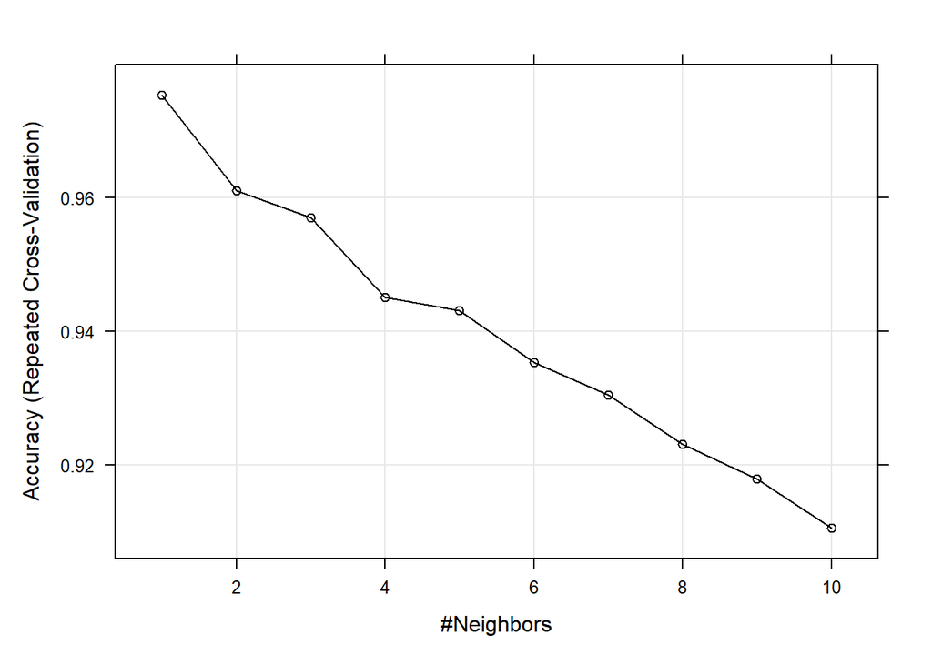

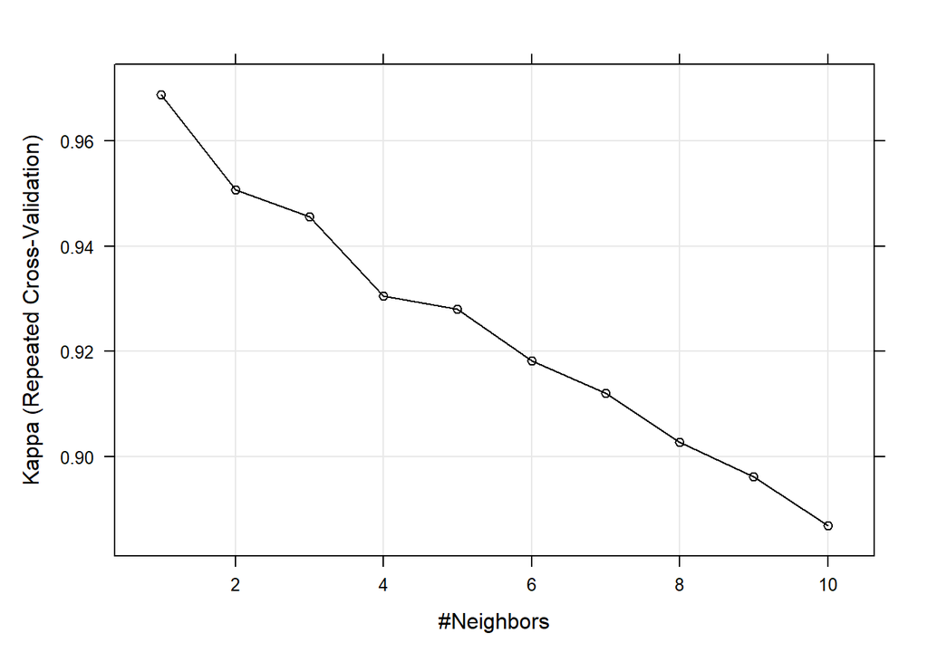

```
## k-Nearest Neighbors
##
## 11776 samples
##    52 predictor
##     5 classes: 'A', 'B', 'C', 'D', 'E'
##
## Pre-processing: centered (52), scaled (52)
## Resampling: Cross-Validated (10 fold, repeated 3 times)
## Summary of sample sizes: 10598, 10600, 10598, 10598, 10599, 10599, ...
## Resampling results across tuning parameters:
##
##   k   Accuracy   Kappa
##    1  0.9753736  0.9688513
##    2  0.9609936  0.9506619
##    3  0.9569467  0.9455329
##    4  0.9450860  0.9305210
##    5  0.9431054  0.9280097
##    6  0.9353205  0.9181589
##    7  0.9304522  0.9119937
##    8  0.9230919  0.9026797
##    9  0.9179119  0.8961357
##   10  0.9105241  0.8867922
##
## Accuracy was used to select the optimal model using the largest value.
## The final value used for the model was k = 1.
```

```
## 1-nearest neighbor model
## Training set outcome distribution:
##
##    A    B    C    D    E
## 3348 2279 2054 1930 2165
```

STATISTICS

The value of Kappa is selected with a very small p-value and within a 95% confidence.

THE DISTRIBUTION PREDICTED BY THE MODEL IS VERY SIMILAR TO THE DISTRIBUTION OF THE DATA IN BOTH THE TRAINING SET AND VALIDATION

MODEL PREDICTIONS (Validation and Test) The model predictions distribution is very similar to the real distribution of the data set.

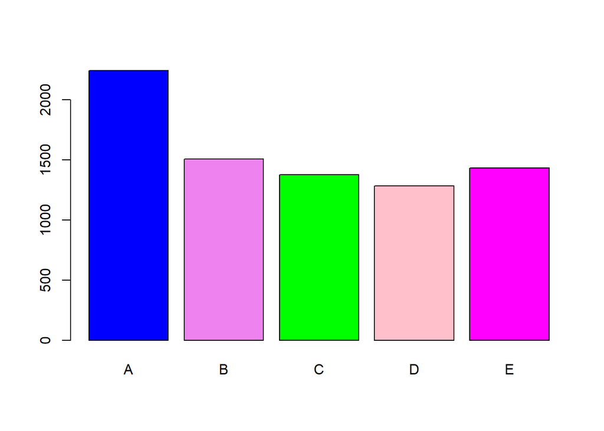

```
## [1] "train_preds"       "validation.classe"
```

[output not shown]

CONFUSION MATRIX The confusion matrix shows some misclassifications.

```
## Confusion Matrix and Statistics
##
##           Reference
## Prediction    A    B    C    D    E
##          A 2209   21    8    3    3
##          B   12 1472   10    8    5
##          C    5   21 1322   21    7
##          D    2    1   25 1250    6
##          E    4    3    3    4 1421
##
## Overall Statistics
##
##                Accuracy : 0.9781
##                  95% CI : (0.9746, 0.9812)
##     No Information Rate : 0.2845
##     P-Value [Acc > NIR] : <2e-16
##
##                   Kappa : 0.9723
##
##  Mcnemar's Test P-Value : 0.109
##
## Statistics by Class:
##
##                      Class: A Class: B Class: C Class: D Class: E
## Sensitivity            0.9897   0.9697   0.9664   0.9720   0.9854
## Specificity            0.9938   0.9945   0.9917   0.9948   0.9978
## Pos Pred Value         0.9844   0.9768   0.9608   0.9735   0.9902
## Neg Pred Value         0.9959   0.9927   0.9929   0.9945   0.9967
## Prevalence             0.2845   0.1935   0.1744   0.1639   0.1838
## Detection Rate         0.2815   0.1876   0.1685   0.1593   0.1811
## Detection Prevalence   0.2860   0.1921   0.1754   0.1637   0.1829
## Balanced Accuracy      0.9917   0.9821   0.9790   0.9834   0.9916
```

ROC Curve

The ROC curve displays sensitivity versus specificity values as it traces off all different threshold points (0 – 1). We can compare this curve to other ROC curves and see which model performs better. AUC represents a degree or measure of separability. It tells us how much the model is capable of distinguishing between classes. Higher the AUC, better the model is at predicting the probability of class A higher than the probability of class B.

The graph below indicates that a threshold value of 0.33, the number of correctly classified true values, is almost equal to the number of correctly classified false values. The area under the curve indicates that this model is good at predicting true and false values.

The Diagonal line represents the threshold (50%) where the true positive rate and false positive rate are equal. In the case of the graph displayed below, the false positive rate would start at the right end of the x- axis and would end at the left end of the x- axis. The base case represents the threshold at which the model is equally likely to predict true or false.

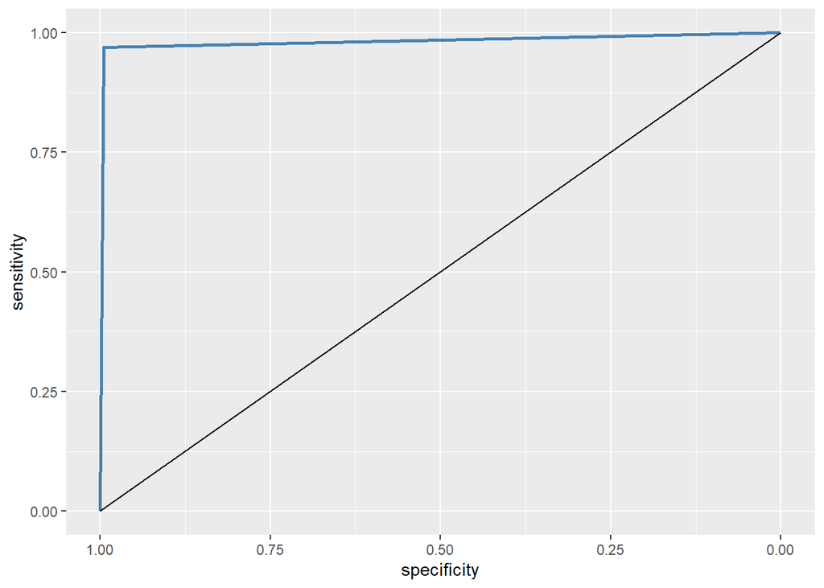

```
##
## Call:
## multiclass.roc.default(response = validation$classe, predictor = model_knn_prediction,     plot = FALSE, print.thres = TRUE, col = "blue")
##
## Data: multivariate predictor model_knn_prediction with 5 levels of validation$classe: A, B, C, D, E.
## Multi-class area under the curve: 0.9854
```

PREDICTIONS MADE BY THE MODEL USNNG THE TEST SET

```
##  [1] B A A A A E D B A A B C B A E E A B B B
## Levels: A B C D E
```

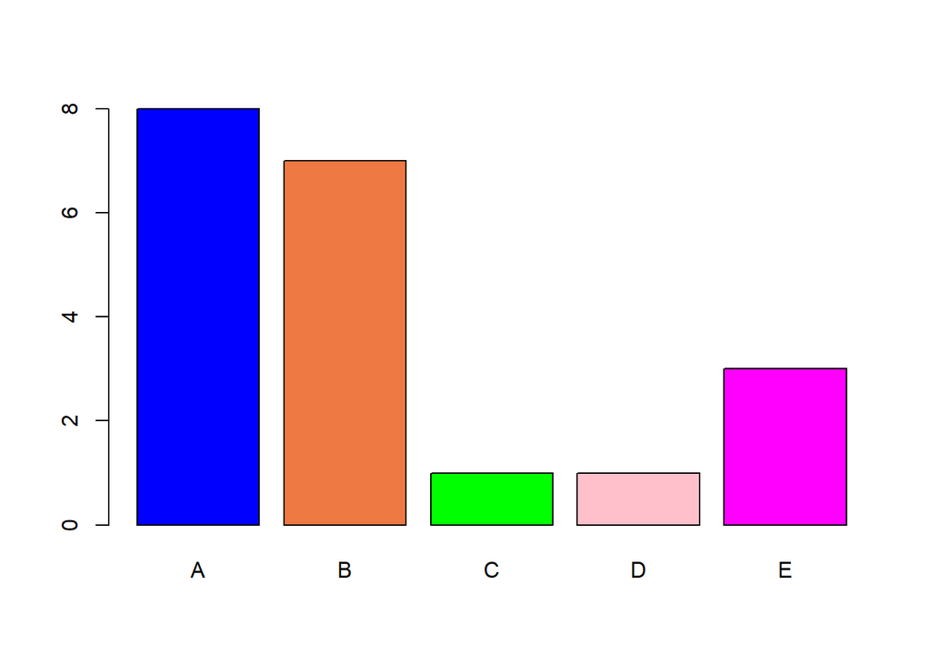

```
##    A B C D E class
## 1  0 1 0 0 0     B
## 2  1 0 0 0 0     A
## 3  1 0 0 0 0     A
## 4  1 0 0 0 0     A
## 5  1 0 0 0 0     A
## 6  0 0 0 0 1     E
## 7  0 0 0 1 0     D
## 8  0 1 0 0 0     B
## 9  1 0 0 0 0     A
## 10 1 0 0 0 0     A
## 11 0 1 0 0 0     B
## 12 0 0 1 0 0     C
## 13 0 1 0 0 0     B
## 14 1 0 0 0 0     A
## 15 0 0 0 0 1     E
## 16 0 0 0 0 1     E
## 17 1 0 0 0 0     A
## 18 0 1 0 0 0     B
## 19 0 1 0 0 0     B
## 20 0 1 0 0 0     B
```

If we look at the summary of the model, it shows the statistics for all splits. The printcp and plotcp functions provide the cross-validation error for each nsplit and can be used to prune the tree. The one with least cross-validated error (xerror) is the optimal value of CP given by the printcp() function.

```
## CART
##
## 11776 samples
##    52 predictor
##     5 classes: 'A', 'B', 'C', 'D', 'E'
##
## No pre-processing
## Resampling: Cross-Validated (5 fold, repeated 5 times)
## Summary of sample sizes: 9420, 9422, 9420, 9421, 9421, 9421, ...
## Resampling results across tuning parameters:
##
##   cp          Accuracy   Kappa
##   0.03731609  0.5320657  0.39754237
##   0.05995887  0.4129774  0.20307703
##   0.11627907  0.3295160  0.06881491
##
## Accuracy was used to select the optimal model using the largest value.
## The final value used for the model was cp = 0.03731609.
```

PLOT OF COMPLEXITY VERSUS KAPPA

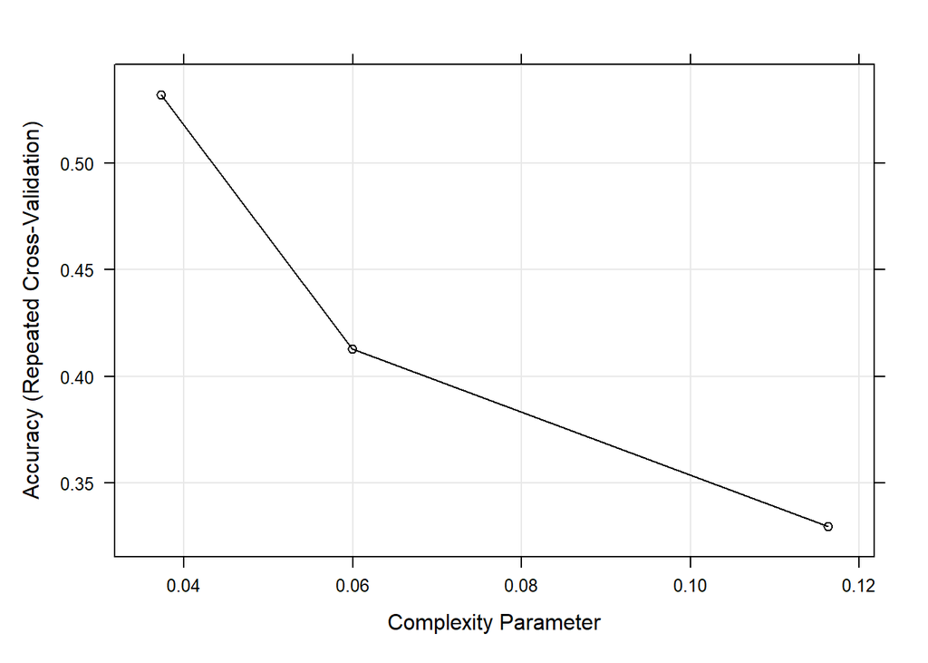

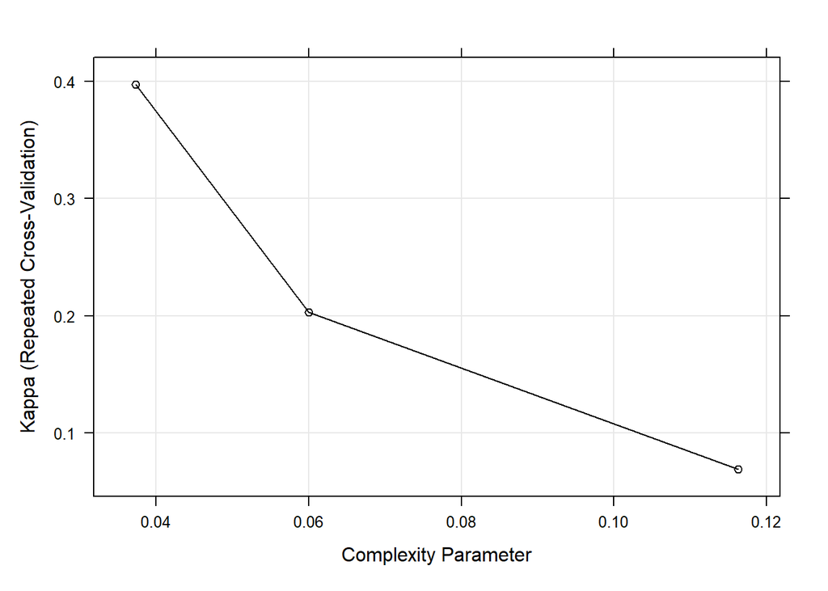

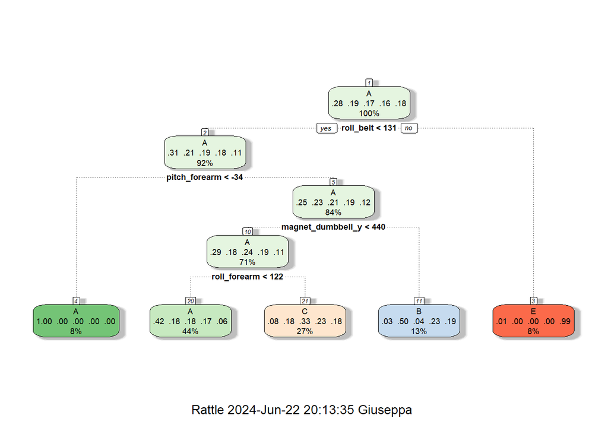

PREDICTED DISTRIBUTION (Validation Set)

This model does not seem to predict the real distribution of the validation set as was seen with the KNN model, which seems to be related to the values of Kappa and Accuracy obtained previously.

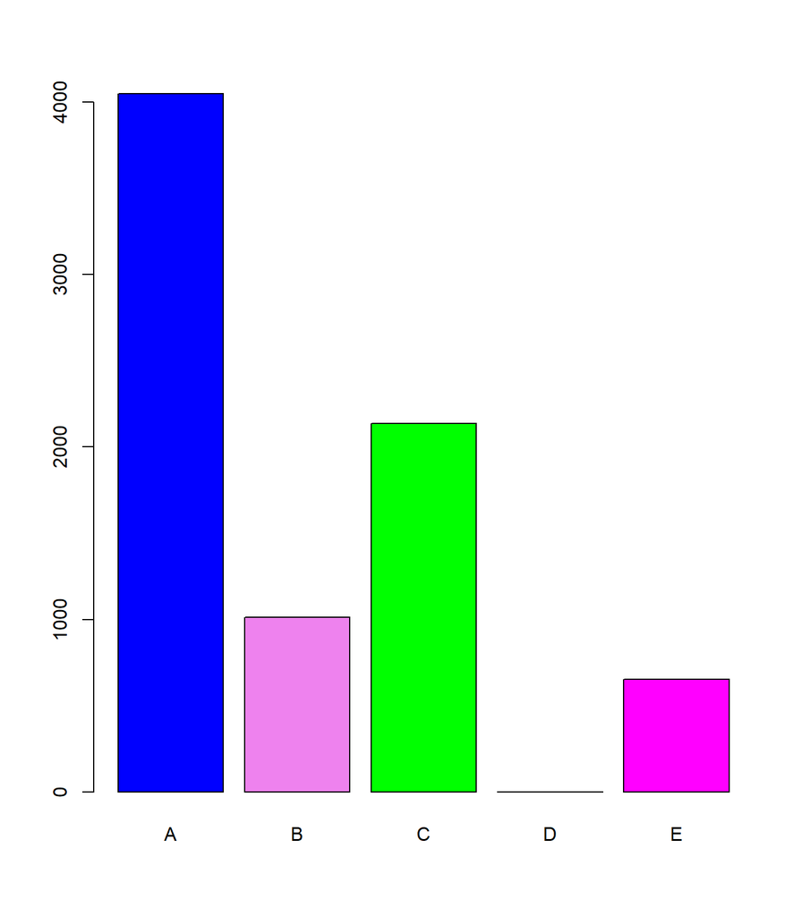

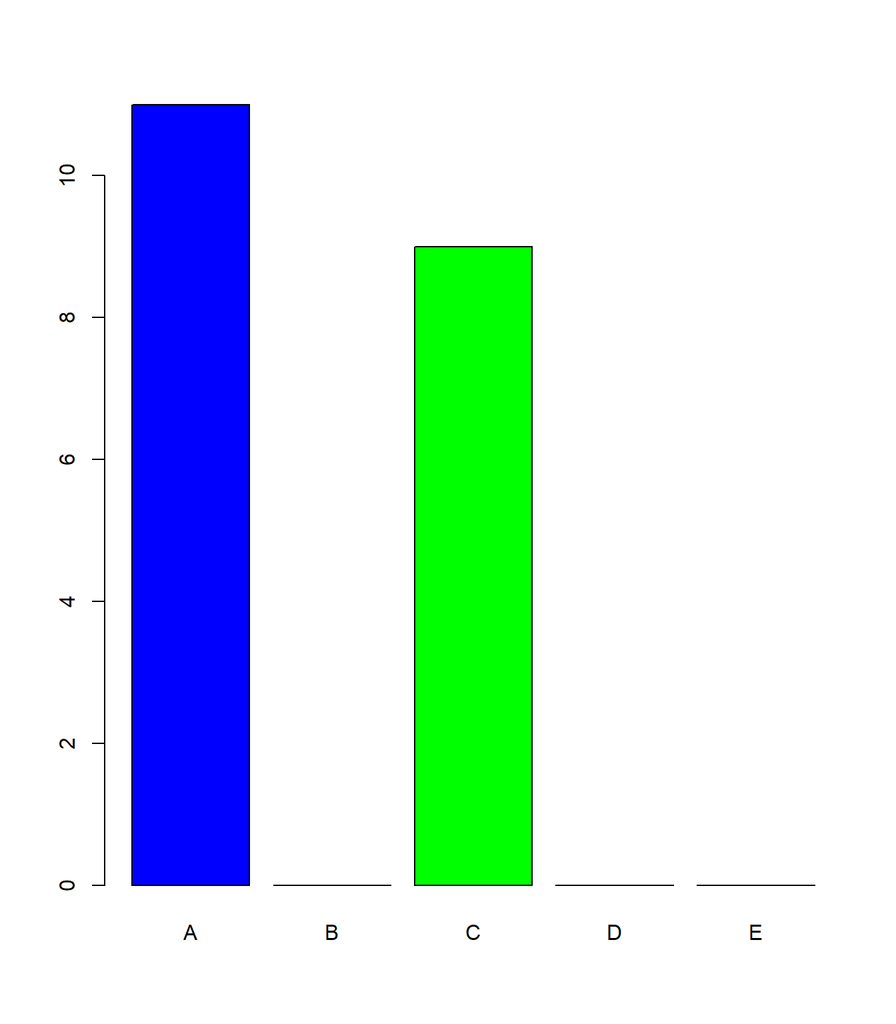

STATISTICS

CONFUSION MATRIX

The confusion matrix shows many classification error and this agrees with the values of “accuracy and Kappa”, therefore I can conclude that this is not a reliable model for the data.

```
## Confusion Matrix and Statistics
##
##           Reference
## Prediction    A    B    C    D    E
##          A 2016  618  639  564  210
##          B   30  525   47  218  191
##          C  178  375  682  504  396
##          D    0    0    0    0    0
##          E    8    0    0    0  645
##
## Overall Statistics
##
##                Accuracy : 0.493
##                  95% CI : (0.4819, 0.5041)
##     No Information Rate : 0.2845
##     P-Value [Acc > NIR] : < 2.2e-16
##
##                   Kappa : 0.3378
##
##  Mcnemar's Test P-Value : NA
##
## Statistics by Class:
##
##                      Class: A Class: B Class: C Class: D Class: E
## Sensitivity            0.9032  0.34585  0.49854   0.0000  0.44730
## Specificity            0.6382  0.92320  0.77570   1.0000  0.99875
## Pos Pred Value         0.4981  0.51929  0.31944      NaN  0.98775
## Neg Pred Value         0.9431  0.85472  0.87988   0.8361  0.88920
## Prevalence             0.2845  0.19347  0.17436   0.1639  0.18379
## Detection Rate         0.2569  0.06691  0.08692   0.0000  0.08221
## Detection Prevalence   0.5158  0.12886  0.27211   0.0000  0.08323
## Balanced Accuracy      0.7707  0.63452  0.63712   0.5000  0.72302
```

ROC Curve

The ROC curve displays sensitivity versus specificity values as it traces off all different threshold points (0 – 1). We can compare this curve to other ROC curves and see which model performs better. The graph below indicates that a threshold value of 0.591, the number of correctly classified true values, is almost equal to the number of correctly classified false values. The area under the curve indicates that this model is not good at predicting true and false values.

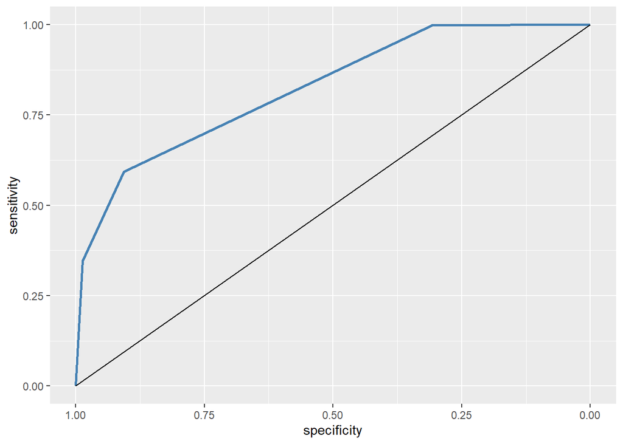

RANDOM FOREST

Using cross validation will allow to you avoid overfitting. Choosing your best model based on CV results will lead to a model that hasn’t overfit,

KAPPA VERSUS RANDOMLY SELECTED PREDICTORS

If splitting a node generates two nodes for which one is smaller than node size then the node is not split, and it becomes a leaf node. mtry: Number of variables randomly sampled as candidates at each split. ntree: Number of trees to grow.

```
## Random Forest
##
## 11776 samples
##    52 predictor
##     5 classes: 'A', 'B', 'C', 'D', 'E'
##
## No pre-processing
## Resampling: Cross-Validated (10 fold, repeated 1 times)
## Summary of sample sizes: 10598, 10600, 10598, 10598, 10599, 10599, ...
## Resampling results across tuning parameters:
##
##   mtry  Accuracy   Kappa
##    1    0.3552005  0.1136646
##    2    0.3871355  0.1634006
##    3    0.4265424  0.2235751
```

[output cut: 45 more lines]

ACCURACY VERSUS NUMBER OF RANDOMMLY SELECTED PREDICTORS

The plot below demonstrates that the accuracy value increases as the number of randomly selected predictors increases.

FINAL RANDOM FOREST MODEL

Plotting the final model will plot the error rates on the training and test data sets as the number of trees are increased.

For the final model, I chose node size 8, number of nodes 9 and number of trees 10. This selection was based on the amount of error versus the number of trees. This error stabilizes for the parameters above as shown in the plot below.NODESIZE 8 – MAXNODES 9 I CHOSE THIS ONE – NTREES 10

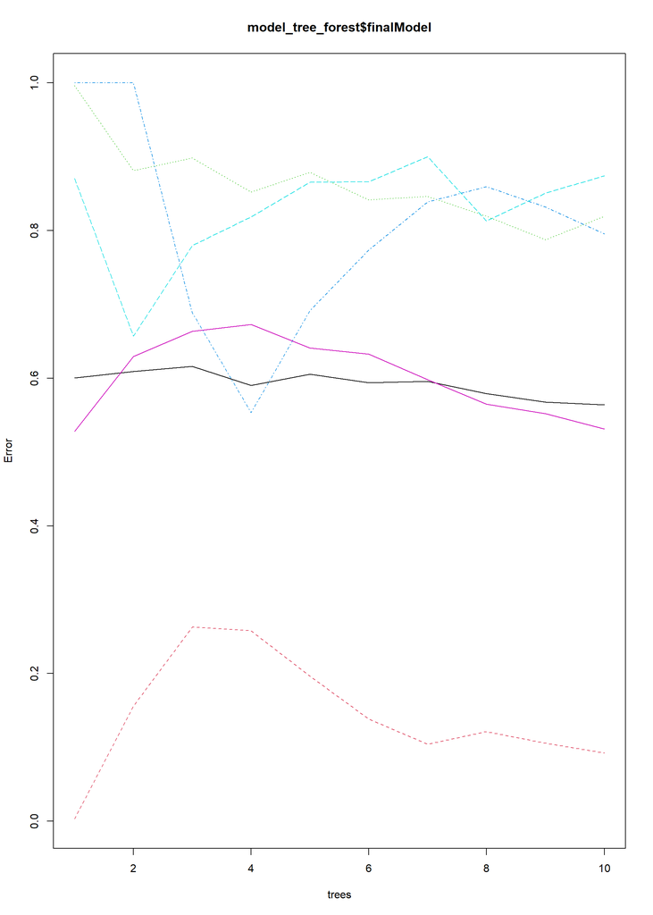

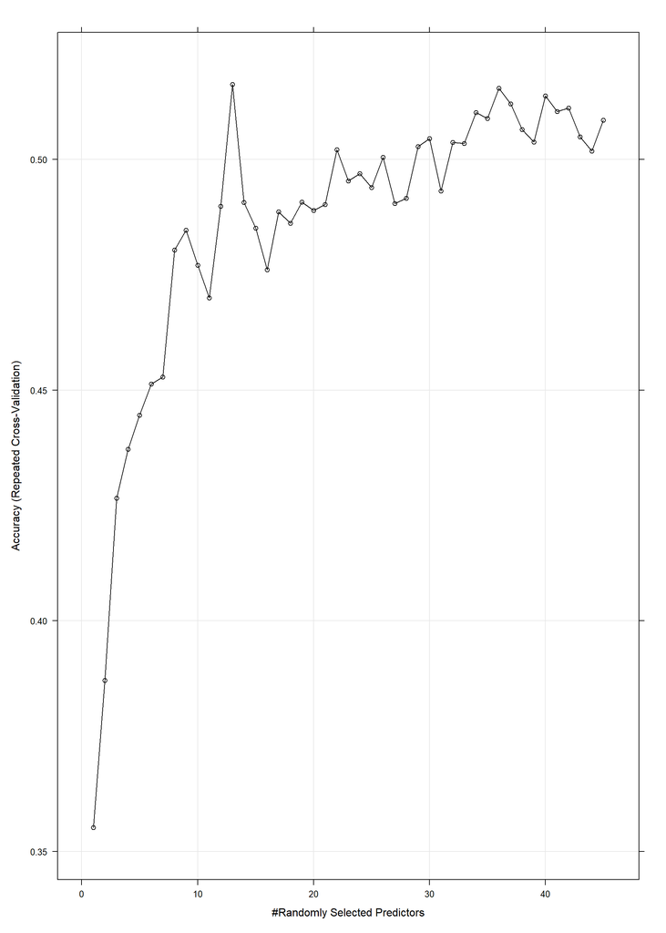

```
##   model parameter                         label forReg forClass probModel
## 1    rf      mtry #Randomly Selected Predictors   TRUE     TRUE      TRUE
```

RESULTS

The optimal model was selected based on the value of accuracy for th parameter mtry value selection. The parameter mtry determines how many variables will be included in the first split. The largest value of accuracy was used to select the mtry value. This was mtry = 39.

VARIABLE IMPORTANCE

Variable importance is calculated by considering the average increase in node purity a split on that variable causes. Variables whose splits cause larger increases in node purity are more important. The first split typically causes the largest increase in node purity. I am assuming that min depth in this package means what is the first time this variable is used to split the tree. If this is the case it makes sense that more important variables have lower min depth values. The splits that causes the larger increases in purity happen early and so the important variables are split on early.

I chose to display only the 10 most important variables. Variable importance is chosen based on the value of the gene coefficient. The Gini Coefficient is measures in terms of the homogeneity of nodes in the random forest. The Mean Decrease accuracy and the mean decrease Gini Coefficient are directly proportional to each other. When a tree is built, the decision about which variable to used to split the data at each node uses the calculation of the Gini impurity. For each variable, the sum of the Gini decrease across every tree of the forest is accumulated every time that a variable is used to split a nodeVariable importance helps to determine which . features are more relevant for the splits.

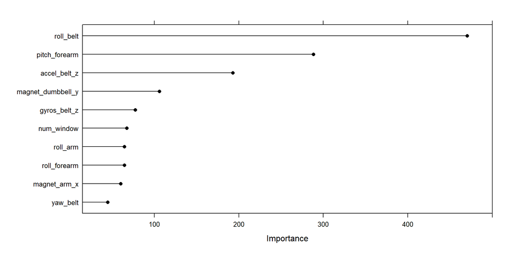

```
## [1] "train_preds"       "validation.classe"
```

CONFUSION MATRIX AND STATISTICS

Confusion matrix demonstrates that there are many misclassifications, and the values or “Accuracy” and “Kappa” are very small; The values of accuracy are within a very narrow confidence interval of values for a small p value which for the high probability of that accuracy value. Therefore we cannot trust the predictons made by this model. Sensitivity. The values of precision and sensitivity indicate that the model’s ability to predict classes correctly is very low. The values of prevalence are similar across all the classes, which indicates that there are no imbalances in the data.

```
## Confusion Matrix and Statistics
##
##           Reference
## Prediction    A    B    C    D    E
##          A 2219 1091 1246 1115  458
##          B    1  363   18   14   97
##          C   12   64  104   93  163
##          D    0    0    0   64    2
##          E    0    0    0    0  722
##
## Overall Statistics
##
##                Accuracy : 0.4425
##                  95% CI : (0.4315, 0.4536)
##     No Information Rate : 0.2845
##     P-Value [Acc > NIR] : < 2.2e-16
##
##                   Kappa : 0.2442
##
##  Mcnemar's Test P-Value : < 2.2e-16
##
## Statistics by Class:
##
##                      Class: A Class: B Class: C Class: D Class: E
## Sensitivity            0.9942  0.23913  0.07602 0.049767  0.50069
## Specificity            0.3035  0.97946  0.94875 0.999695  1.00000
## Pos Pred Value         0.3620  0.73631  0.23853 0.969697  1.00000
## Neg Pred Value         0.9924  0.84292  0.82942 0.842931  0.89893
## Prevalence             0.2845  0.19347  0.17436 0.163905  0.18379
## Detection Rate         0.2828  0.04627  0.01326 0.008157  0.09202
## Detection Prevalence   0.7812  0.06283  0.05557 0.008412  0.09202
## Balanced Accuracy      0.6489  0.60929  0.51239 0.524731  0.75035
```

```
##  [1] A A A A A A A A A A A A A A A A A A A A
## Levels: A B C D E
```

ROC Curve

```r
rocobj <- roc(validation$classe, model_tree_forest_predict[, 2])
```

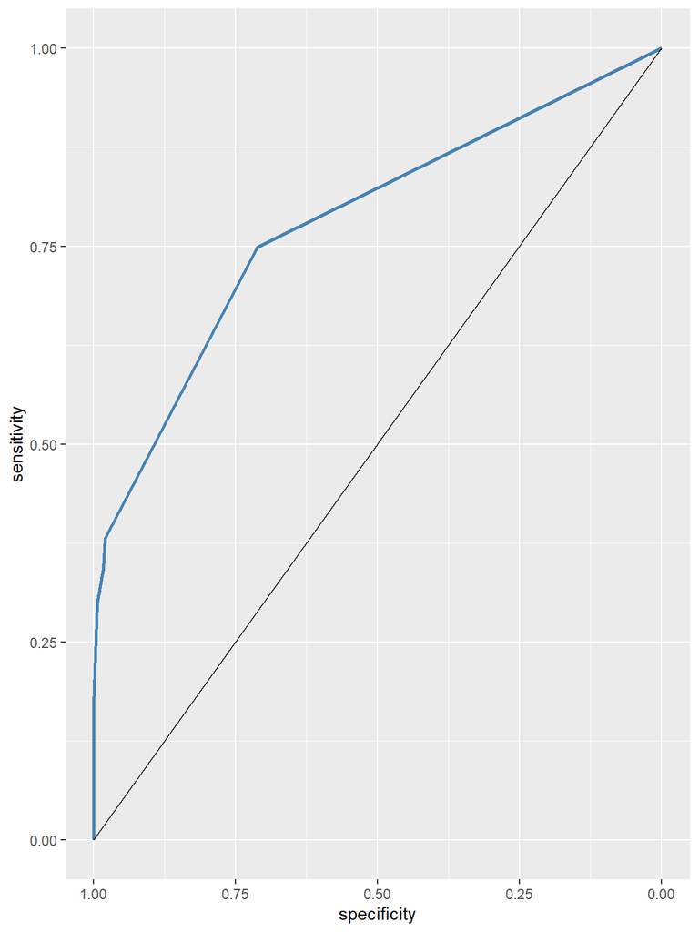

```r
#create ROC plot

ggroc(rocobj, colour = 'steelblue', linetype = 1, size = 1) +

geom_segment(aes(x = 1, xend = 0, y = 0, yend = 1))
```

LDA MODEL

One of the key assumptions of linear discriminant analysis is that each of the predictor variables have the same variance. An easy way to assure that this assumption is met is to scale each variable such that it has a mean of 0 and a standard deviation of 1. This model has no parameters to plot.

RESULTS

The model selects 4 discriminant functions

```
## Linear Discriminant Analysis
##
## 11776 samples
##    52 predictor
##     5 classes: 'A', 'B', 'C', 'D', 'E'
##
## Pre-processing: centered (52), scaled (52)
## Resampling: Cross-Validated (5 fold, repeated 5 times)
## Summary of sample sizes: 9421, 9420, 9421, 9421, 9421, 9422, ...
## Resampling results:
##
##   Accuracy   Kappa
##   0.7142155  0.6383239
```

```
## Call:
## lda(x, grouping = y, type = "prob")
##
## Prior probabilities of groups:
##         A         B         C         D         E
## 0.2843071 0.1935292 0.1744226 0.1638927 0.1838485
##
## Group means:
##   new_windowyes num_window    roll_belt   pitch_belt      yaw_belt gyros_belt_x
## A   0.001617700 -0.1891211 -0.068682997  0.004645818 -0.0002640406  0.002367705
## B   0.003669025  0.2840053  0.003832771 -0.012877471 -0.0304165773  0.006592074
## C   0.003117466  0.2167039 -0.010667854 -0.076527647  0.0389006912 -0.039403473
## D  -0.030665482 -0.0013244 -0.047205851  0.068990841 -0.0650341006 -0.027967962
## E   0.018015397 -0.2109119  0.154380994  0.017472989  0.0534952342  0.051714774
##   gyros_belt_y gyros_belt_z accel_belt_x accel_belt_y accel_belt_z
## A  0.007426118  0.028080291  -0.02200659  -0.02990560  0.086089622
## B  0.022861142 -0.014894296   0.01775822   0.05706069 -0.001147674
## C -0.016465844 -0.011730671   0.06797227   0.01415616  0.032192667
## D -0.033291358 -0.028195390  -0.08497024   0.02066016  0.023485789
## E  0.009750569  0.008518794   0.02659796  -0.04566662 -0.183401301
##   magnet_belt_x magnet_belt_y magnet_belt_z    roll_arm   pitch_arm     yaw_arm
## A    0.03831933    0.23317441    0.11156102 -0.25155648  0.25596168 -0.14114406
## B   -0.10149754    0.16292362    0.14179796  0.19726007 -0.06569383  0.12676540
## C    0.03262290    0.17524265    0.12862584  0.10833732  0.08771385  0.06188716
## D   -0.10241126    0.00846432    0.07715085  0.04749323 -0.18715603  0.07046548
## E    0.10792890   -0.70589164   -0.51259235  0.03624417 -0.24304691 -0.03670330
##   total_accel_arm  gyros_arm_x gyros_arm_y  gyros_arm_z accel_arm_x accel_arm_y
## A      0.15611609 -0.021843042  0.05094307 -0.011153688 -0.38790053  0.12441999
## B      0.10757656  0.007049748 -0.04862603  0.001155980  0.08867939 -0.05884434
## C     -0.09915184  0.036455438 -0.01205377  0.004745515 -0.09337300  0.08490092
## D     -0.21659832 -0.016942123  0.01742873 -0.006396776  0.41304329 -0.07654417
## E     -0.06750625  0.006874345 -0.03169408  0.017231667  0.22688463 -0.14277511
##   accel_arm_z magnet_arm_x magnet_arm_y magnet_arm_z roll_dumbbell
## A -0.01624345  -0.46570885    0.3861264   0.32363891   -0.03341796
## B -0.19519403   0.07361037   -0.1189576  -0.34614982    0.17393327
## C  0.11482867  -0.07401853    0.1534286   0.15894203   -0.54345872
## D  0.18863405   0.46608957   -0.2921801  -0.01594862    0.39299308
## E -0.04650880   0.29742097   -0.3569892  -0.27268070    0.03384617
##   pitch_dumbbell yaw_dumbbell total_accel_dumbbell gyros_dumbbell_x
## A    -0.20617446   0.01428942           0.07941320     -0.026391825
```

[output cut: 78 more lines]

```
## yaw_forearm          -0.020928505  0.088977719  0.0252572070  0.1225724854
## total_accel_forearm   0.322067181  0.045951444 -0.0534141840  0.0470233115
## gyros_forearm_x      -0.025201689 -0.064365845  0.1494531468  0.0868952035
## gyros_forearm_y      -0.045934946 -0.104421378  0.0646675549  0.0328706446
## gyros_forearm_z       0.223735490  0.004470204 -0.0826386095 -0.0995528975
## accel_forearm_x       0.606462486  1.942892858 -0.0709170224  0.7476832046
## accel_forearm_y       0.191355555 -0.135778677 -0.1186789084 -0.4787351071
## accel_forearm_z      -1.019571719  0.441336503  0.5136032660 -0.5684956191
## magnet_forearm_x     -0.591223803 -1.273953465  0.0490954911 -0.4548420514
## magnet_forearm_y     -0.493967016 -0.806065497  0.1673908571  0.1927493031
## magnet_forearm_z     -0.056907518 -0.537541897 -0.1205625544  0.4030821201
##
## Proportion of trace:
##    LD1    LD2    LD3    LD4
## 0.4790 0.2428 0.1646 0.1136
```

MODEL [REDICTIONS]

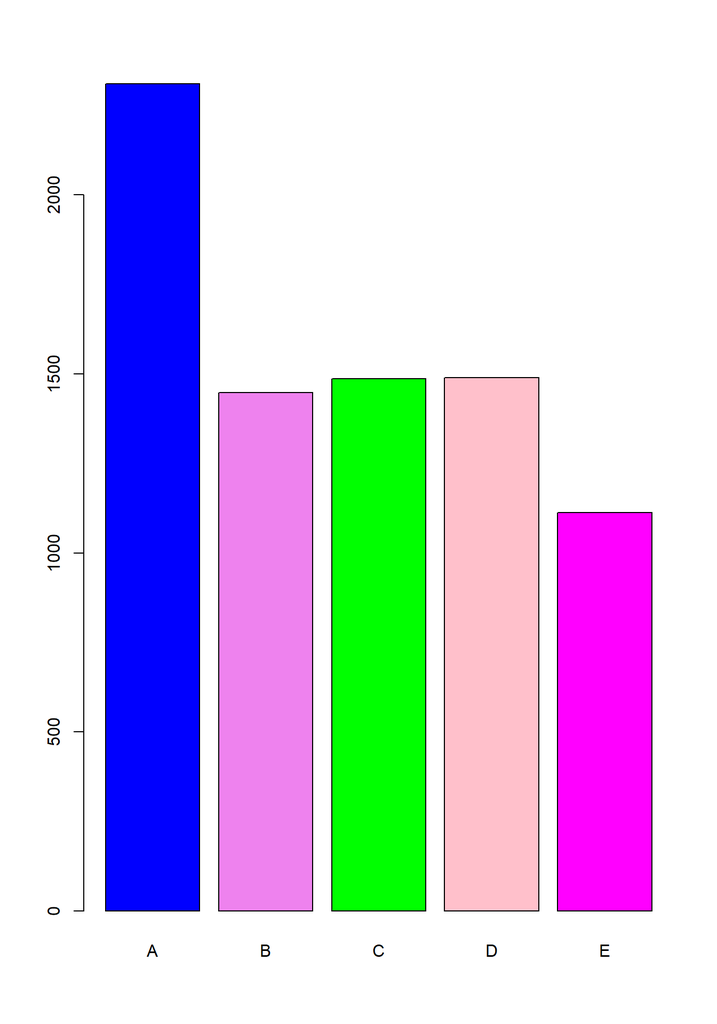

```
## 'data.frame':    7846 obs. of  1 variable:
##  $ validation_class: Factor w/ 5 levels "A","B","C","D",..: 1 1 1 1 1 1 1 1 1 1 ...
```

MODEL PREDICTIONS WITH VALIDATION SET

```
## [1] 7846    2
```

```
## [1] "validation_lda"   "validation_class"
```

CONFUSION MATRIX AND STATISTICS

```
## Confusion Matrix and Statistics
##
##           Reference
## Prediction    A    B    C    D    E
##          A 1827  217  141   65   60
##          B   60  958  140   86  204
##          C  154  185  880  157  110
##          D  180   76  165  937  132
##          E   11   82   42   41  936
##
## Overall Statistics
##
##                Accuracy : 0.7058
##                  95% CI : (0.6956, 0.7159)
##     No Information Rate : 0.2845
##     P-Value [Acc > NIR] : < 2.2e-16
##
##                   Kappa : 0.6278
##
##  Mcnemar's Test P-Value : < 2.2e-16
##
## Statistics by Class:
##
##                      Class: A Class: B Class: C Class: D Class: E
## Sensitivity            0.8185   0.6311   0.6433   0.7286   0.6491
## Specificity            0.9140   0.9226   0.9065   0.9157   0.9725
## Pos Pred Value         0.7909   0.6616   0.5922   0.6289   0.8417
## Neg Pred Value         0.9268   0.9125   0.9233   0.9451   0.9249
## Prevalence             0.2845   0.1935   0.1744   0.1639   0.1838
## Detection Rate         0.2329   0.1221   0.1122   0.1194   0.1193
## Detection Prevalence   0.2944   0.1846   0.1894   0.1899   0.1417
## Balanced Accuracy      0.8663   0.7768   0.7749   0.8222   0.8108
```

MODEL PREDICTIONS WITH TEST SET

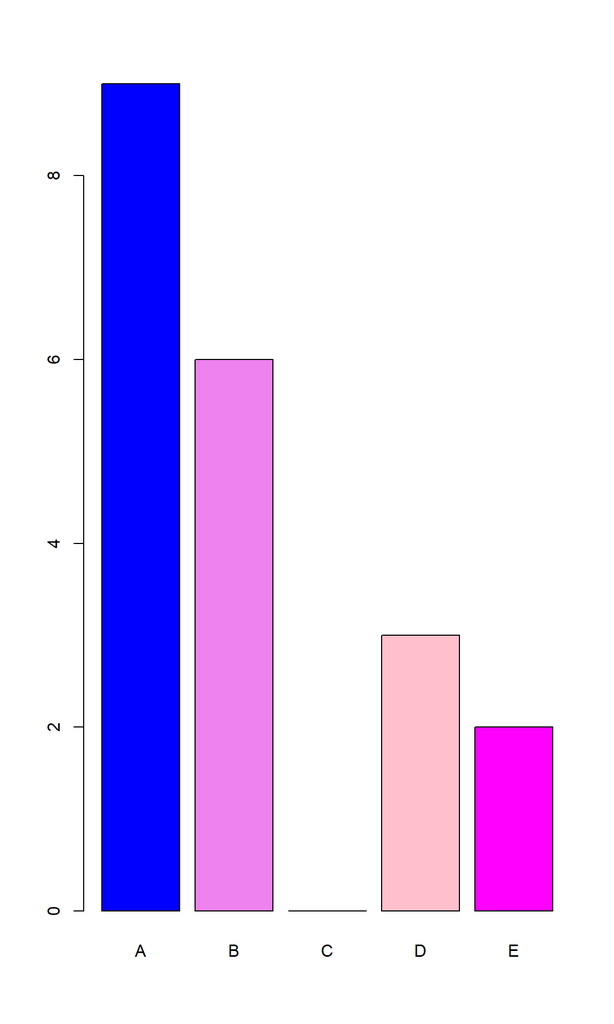

MODEL PREDICTIONS WITH TEST SET

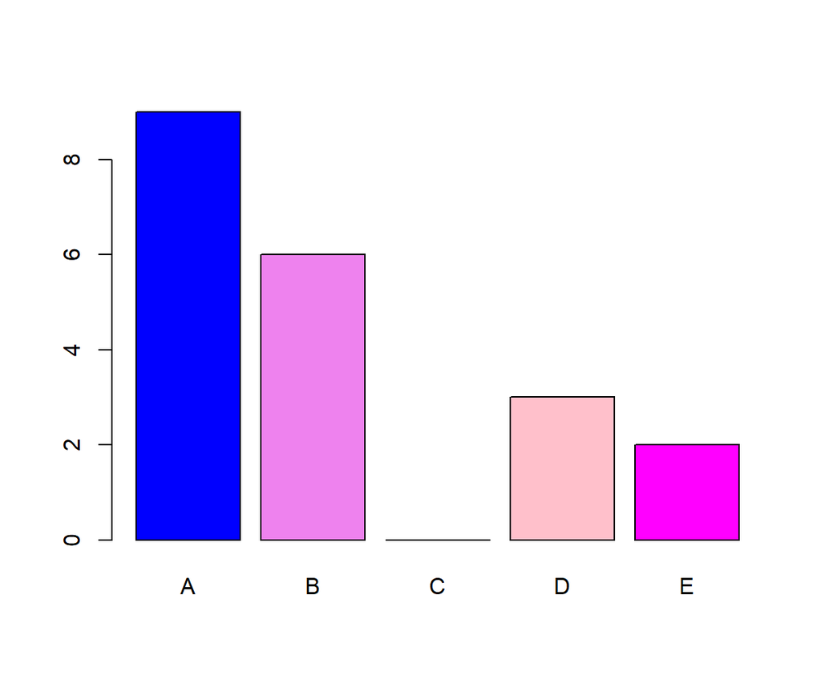

ROC CURVE

The roc curve indicates that a threshold value of 0.113, the number of correctly classified true values, is almost equal to the number of correctly classified false values. The area under the curve indicates that this model is fairly good at predicting true and false values, but this does not agree with the number of misclassification in the consfusion matrix.

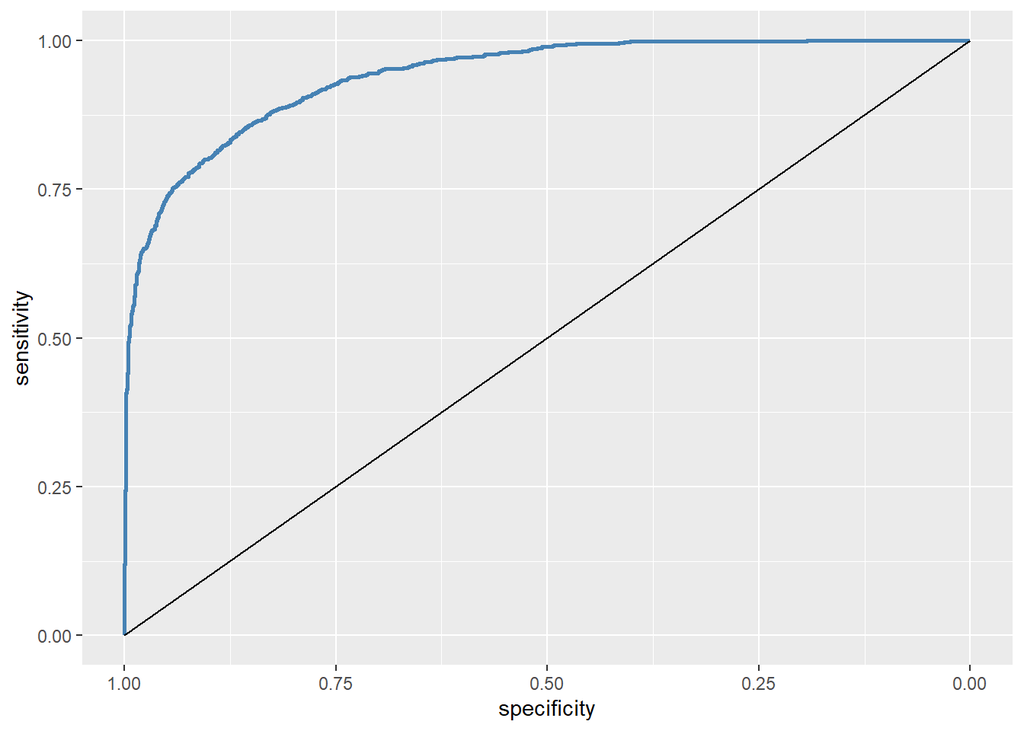

LDA2 MODEL

The Kappa value increases with the number of discriminantt functions and the accuracy value increases with the number of discriminant functions

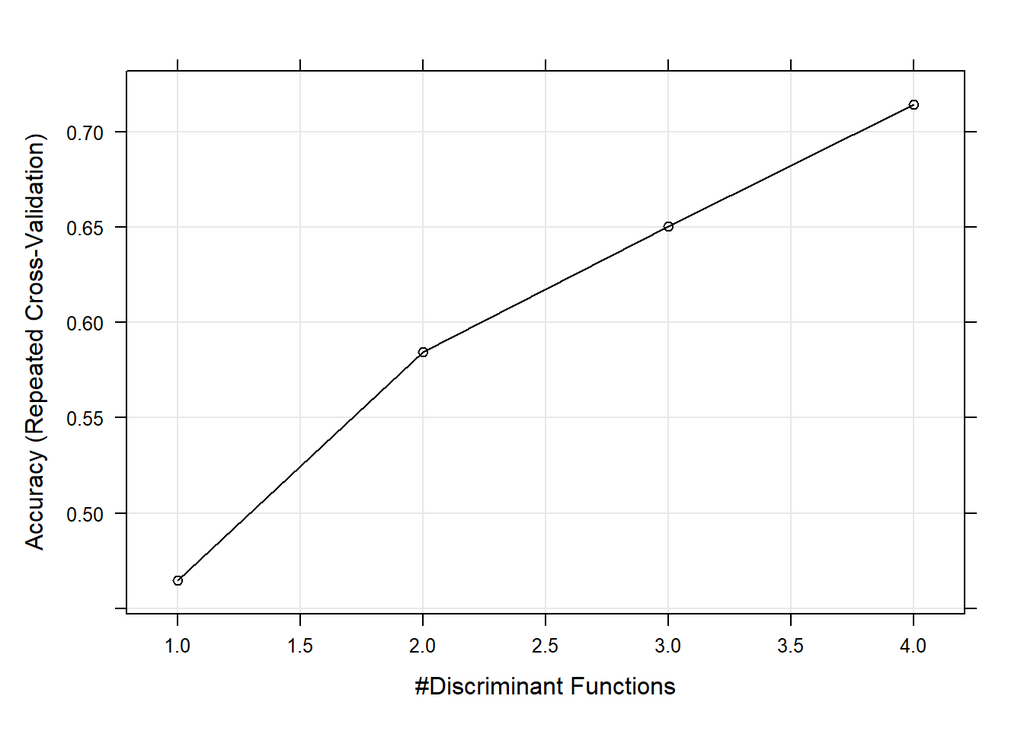

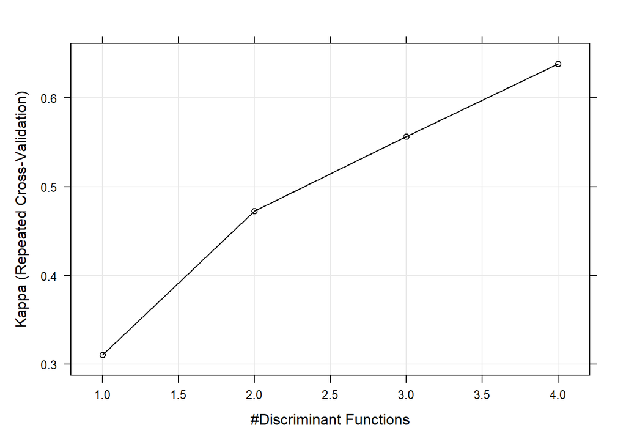

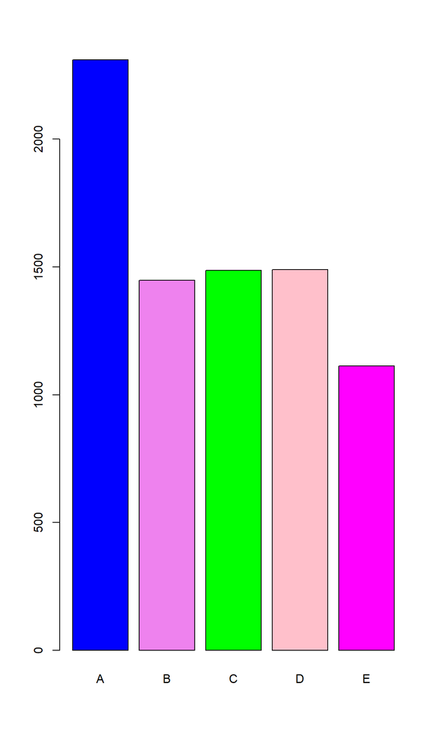

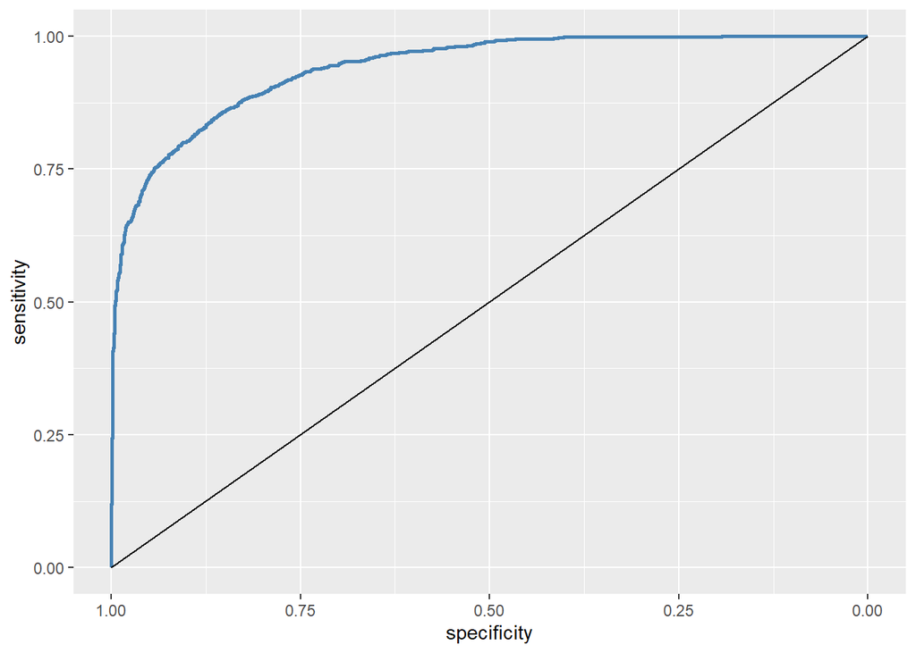

PREDICTIONS WITH TEST SET

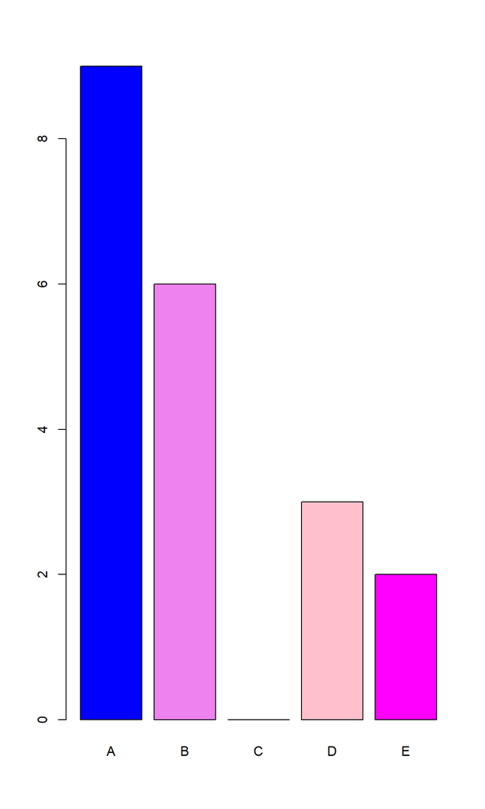

THE BEST MODEL IS KNN BASED ON KAPPA AND ACCURACY

```
##
## Call:
## resamples.default(x = models)
##
## Models: knn, lda2
## Number of resamples: 50
## Performance metrics: Accuracy, Kappa
## Time estimates for: everything, final model fit
```

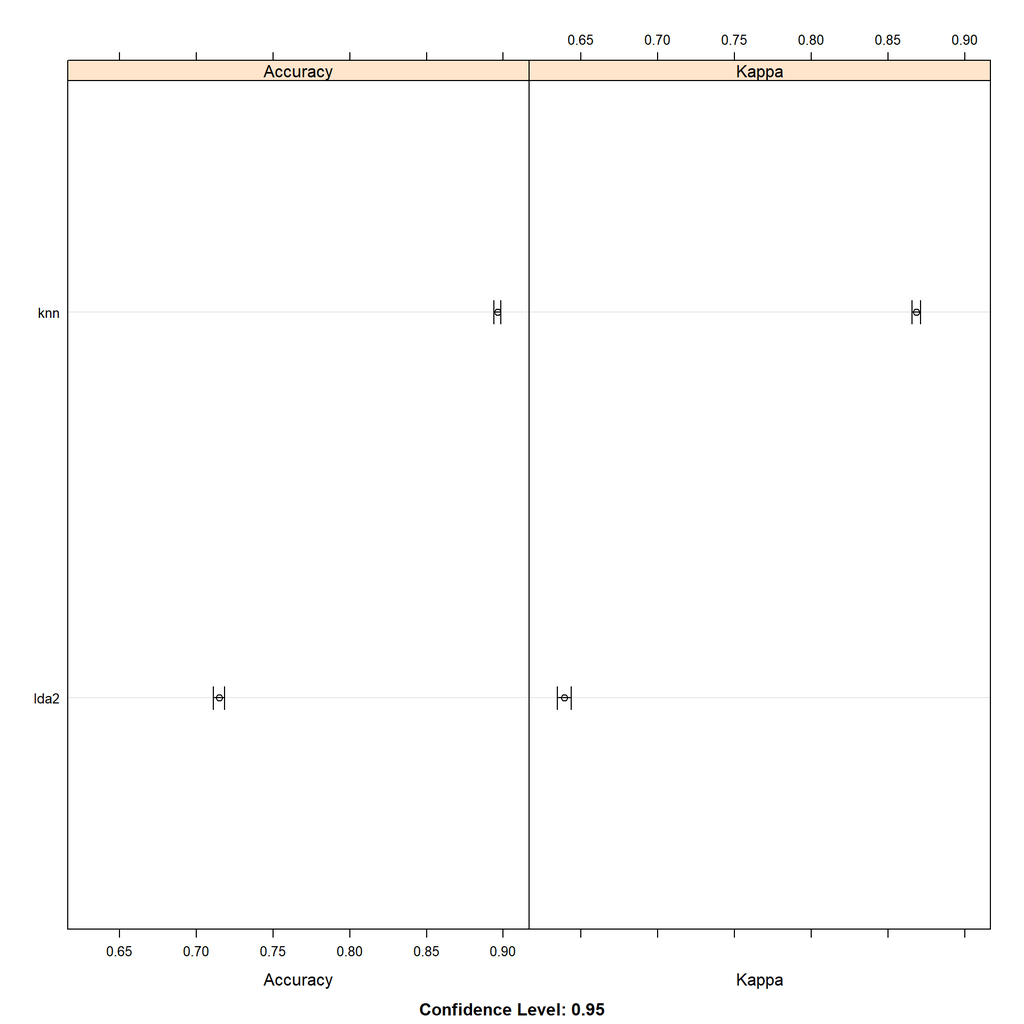

```
## Support Vector Machines with Linear Kernel
##
## 11776 samples
##    52 predictor
##     5 classes: 'A', 'B', 'C', 'D', 'E'
##
## Pre-processing: centered (52), scaled (52)
## Resampling: Cross-Validated (5 fold, repeated 3 times)
## Summary of sample sizes: 9421, 9420, 9420, 9422, 9421, 9421, ...
## Resampling results across tuning parameters:
##
##   C          Accuracy   Kappa
##   0.5000000  0.7822399  0.7232855
##   0.5263158  0.7830324  0.7242903
##   0.5526316  0.7839099  0.7254101
##   0.5789474  0.7837685  0.7252372
##   0.6052632  0.7846460  0.7263492
##   0.6315789  0.7847592  0.7264809
##   0.6578947  0.7853537  0.7272448
##   0.6842105  0.7863444  0.7284940
##   0.7105263  0.7861180  0.7282007
##   0.7368421  0.7863728  0.7285269
##   0.7631579  0.7866275  0.7288433
##   0.7894737  0.7871088  0.7294730
##   0.8157895  0.7871371  0.7295036
##   0.8421053  0.7870521  0.7293862
##   0.8684211  0.7871087  0.7294649
##   0.8947368  0.7876749  0.7301872
##   0.9210526  0.7876465  0.7301528
##   0.9473684  0.7882127  0.7308621
##   0.9736842  0.7881844  0.7308336
##   1.0000000  0.7884392  0.7311722
##
## Accuracy was used to select the optimal model using the largest value.
## The final value used for the model was C = 1.
```

```
##    C
## 20 1
```

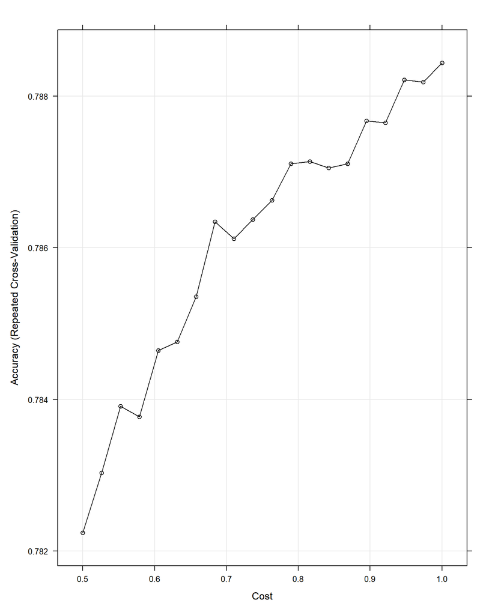

```
## 'data.frame':    7846 obs. of  1 variable:
##  $ validation_linear: Factor w/ 5 levels "A","B","C","D",..: 1 1 1 1 1 1 1 1 1 1 ...
```

```
##  Factor w/ 5 levels "A","B","C","D",..: 1 1 1 1 1 1 1 1 1 1 ...
```

```
## 'data.frame':    7846 obs. of  1 variable:
##  $ validation_class: Factor w/ 5 levels "A","B","C","D",..: 1 1 1 1 1 1 1 1 1 1 ...
```

```
## Confusion Matrix and Statistics
##
##           Reference
## Prediction    A    B    C    D    E
##          A 2041  192  111   75   67
##          B   48 1110  120   60  162
##          C   59   75 1039  151   85
##          D   73   30   41  943   90
##          E   11  111   57   57 1038
##
## Overall Statistics
##
##                Accuracy : 0.7865
##                  95% CI : (0.7773, 0.7955)
##     No Information Rate : 0.2845
##     P-Value [Acc > NIR] : < 2.2e-16
##
##                   Kappa : 0.7288
##
##  Mcnemar's Test P-Value : < 2.2e-16
##
## Statistics by Class:
##
##                      Class: A Class: B Class: C Class: D Class: E
## Sensitivity            0.9144   0.7312   0.7595   0.7333   0.7198
## Specificity            0.9207   0.9384   0.9429   0.9643   0.9631
## Pos Pred Value         0.8210   0.7400   0.7374   0.8012   0.8148
## Neg Pred Value         0.9644   0.9357   0.9489   0.9486   0.9385
## Prevalence             0.2845   0.1935   0.1744   0.1639   0.1838
## Detection Rate         0.2601   0.1415   0.1324   0.1202   0.1323
## Detection Prevalence   0.3168   0.1912   0.1796   0.1500   0.1624
## Balanced Accuracy      0.9176   0.8348   0.8512   0.8488   0.8415
```

```
## Support Vector Machines with Radial Basis Function Kernel
##
## 11776 samples
##    52 predictor
##     5 classes: 'A', 'B', 'C', 'D', 'E'
##
## Pre-processing: centered (52), scaled (52)
## Resampling: Cross-Validated (5 fold, repeated 3 times)
## Summary of sample sizes: 9421, 9420, 9420, 9422, 9421, 9421, ...
## Resampling results across tuning parameters:
##
##   C       Accuracy   Kappa
##     0.25  0.8541945  0.8155882
##     0.50  0.8895486  0.8601340
##     1.00  0.9172607  0.8952090
##     2.00  0.9405566  0.9247180
##     4.00  0.9564929  0.9449121
##     8.00  0.9692876  0.9611194
##    16.00  0.9776382  0.9717021
##    32.00  0.9840921  0.9798727
##    64.00  0.9876303  0.9843511
##   128.00  0.9889890  0.9860709
##
## Tuning parameter 'sigma' was held constant at a value of 0.0135523
## Accuracy was used to select the optimal model using the largest value.
## The final values used for the model were sigma = 0.0135523 and C = 128.
```

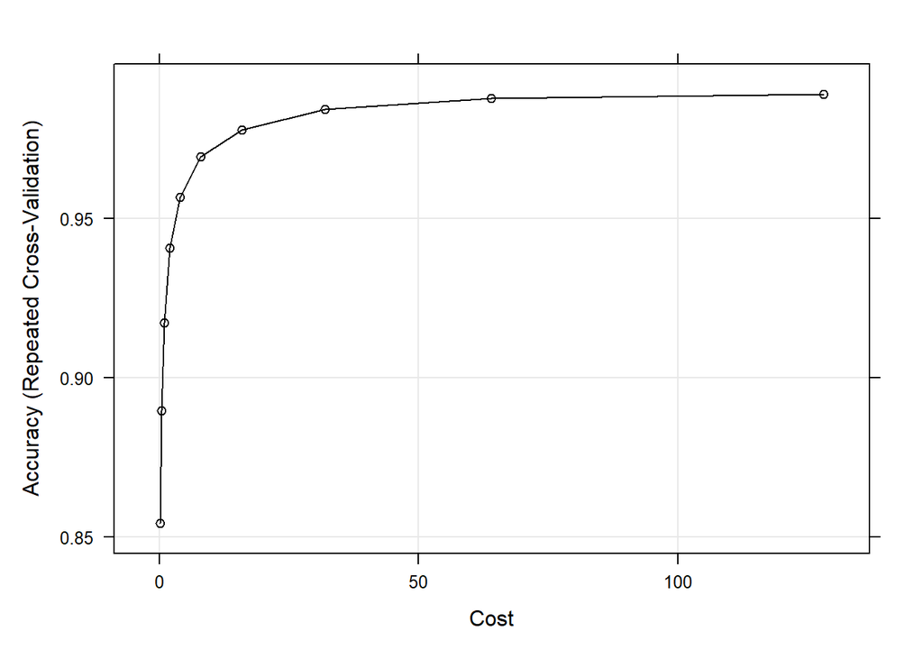